# Température *HadCRUT*

Nous avons décidé ici d'utiliser le package `prince` pour démonstration.

```python
import pandas
import numpy
import matplotlib.pyplot as plt
import seaborn
seaborn.set_style("white")

from prince import PCA
```

```python
temp = pandas.read_table(
    "https://crudata.uea.ac.uk/cru/data/temperature/HadCRUT5.0Analysis_gl.txt",
    sep = "\s+",
    names = ["Jan", "Feb", "Mar", "Apr", "May", "Jun", "Jul", "Aug", "Sep", "Oct", "Nov", "Dec", "Annual"])
temp = temp.iloc[::2]
temp = temp.iloc[:-1] # suppression de la dernière ligne (i.e. 2024 n'est pas finie)
temp
```

|  | Jan | Feb | Mar | Apr | May | Jun | Jul | Aug | Sep | Oct | Nov | Dec | Annual |
| --- | --- | --- | --- | --- | --- | --- | --- | --- | --- | --- | --- | --- | --- |
| 1850 | -0.675 | -0.333 | -0.591 | -0.589 | -0.509 | -0.344 | -0.160 | -0.208 | -0.385 | -0.533 | -0.283 | -0.404 | -0.418 |
| 1851 | -0.201 | -0.469 | -0.646 | -0.542 | -0.198 | -0.137 | -0.097 | -0.102 | -0.091 | -0.008 | -0.082 | -0.228 | -0.233 |
| 1852 | -0.375 | -0.477 | -0.560 | -0.585 | -0.127 | -0.084 | 0.005 | -0.136 | -0.002 | -0.172 | -0.305 | 0.065 | -0.229 |
| 1853 | -0.233 | -0.404 | -0.280 | -0.386 | -0.268 | -0.142 | -0.083 | -0.057 | -0.250 | -0.392 | -0.411 | -0.337 | -0.270 |
| 1854 | -0.381 | -0.361 | -0.243 | -0.334 | -0.289 | -0.299 | -0.179 | -0.239 | -0.217 | -0.095 | -0.410 | -0.450 | -0.292 |
| ... | ... | ... | ... | ... | ... | ... | ... | ... | ... | ... | ... | ... | ... |
| 2019 | 0.800 | 0.844 | 1.076 | 0.939 | 0.778 | 0.809 | 0.857 | 0.858 | 0.803 | 0.956 | 0.937 | 1.037 | 0.891 |
| 2020 | 1.069 | 1.113 | 1.094 | 1.063 | 0.908 | 0.825 | 0.816 | 0.801 | 0.867 | 0.811 | 1.014 | 0.693 | 0.923 |
| 2021 | 0.701 | 0.565 | 0.726 | 0.760 | 0.706 | 0.713 | 0.792 | 0.799 | 0.868 | 0.907 | 0.854 | 0.751 | 0.762 |
| 2022 | 0.779 | 0.764 | 0.890 | 0.770 | 0.761 | 0.858 | 0.778 | 0.853 | 0.790 | 0.929 | 0.675 | 0.768 | 0.801 |
| 2023 | 0.779 | 0.869 | 1.125 | 0.927 | 0.871 | 1.052 | 1.150 | 1.199 | 1.352 | 1.287 | 1.334 | 1.259 | 1.100 |

174 rows × 13 columns

## Description

- Pas de données manquantes
- Des moyennes globalement similaires
- Idem pour la variance
- Pas de distribution dissymétrique, mais quelques valeurs extrêmes toutefois.

```python
temp.describe().round(2)
```

|  | Jan | Feb | Mar | Apr | May | Jun | Jul | Aug | Sep | Oct | Nov | Dec | Annual |
| --- | --- | --- | --- | --- | --- | --- | --- | --- | --- | --- | --- | --- | --- |
| count | 174.00 | 174.00 | 174.00 | 174.00 | 174.00 | 174.00 | 174.00 | 174.00 | 174.00 | 174.00 | 174.00 | 174.00 | 174.00 |
| mean | -0.10 | -0.10 | -0.12 | -0.08 | -0.09 | -0.06 | -0.04 | -0.02 | -0.04 | -0.04 | -0.08 | -0.11 | -0.07 |
| std | 0.42 | 0.43 | 0.45 | 0.41 | 0.38 | 0.36 | 0.35 | 0.36 | 0.36 | 0.39 | 0.41 | 0.42 | 0.38 |
| min | -1.04 | -0.84 | -0.84 | -0.66 | -0.66 | -0.64 | -0.59 | -0.60 | -0.64 | -0.68 | -0.68 | -0.90 | -0.60 |
| 25% | -0.39 | -0.41 | -0.43 | -0.39 | -0.35 | -0.31 | -0.29 | -0.27 | -0.30 | -0.33 | -0.39 | -0.41 | -0.34 |
| 50% | -0.18 | -0.22 | -0.21 | -0.18 | -0.17 | -0.15 | -0.12 | -0.11 | -0.13 | -0.09 | -0.14 | -0.21 | -0.18 |
| 75% | 0.14 | 0.12 | 0.11 | 0.15 | 0.12 | 0.10 | 0.09 | 0.13 | 0.12 | 0.11 | 0.07 | 0.11 | 0.09 |
| max | 1.09 | 1.22 | 1.18 | 1.06 | 0.91 | 1.05 | 1.15 | 1.20 | 1.35 | 1.29 | 1.33 | 1.26 | 1.10 |

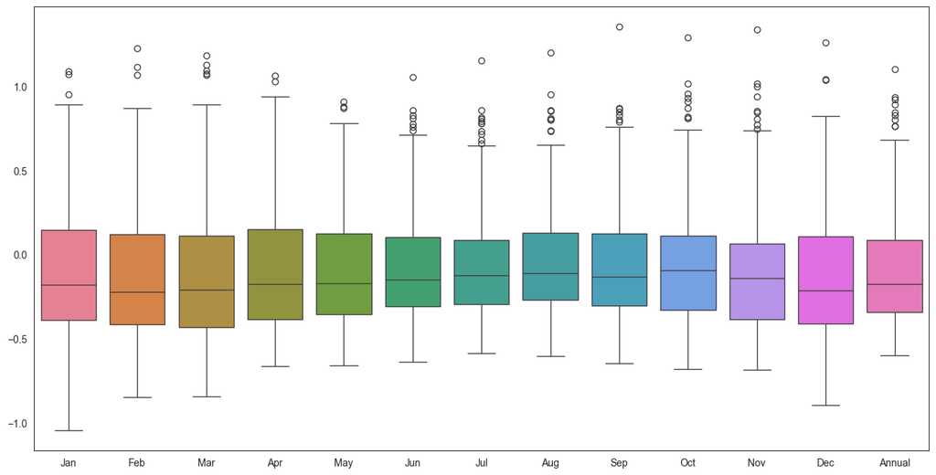

```python
plt.figure(figsize = (16, 8))
seaborn.boxplot(data = temp)
plt.show()
```

## Evolution annuelle sur la période

La représentation de l'évolution des anomalies moyennes annuelles permet de voir que la température est en augmentation, particulièrement depuis le milieu des années 1970.

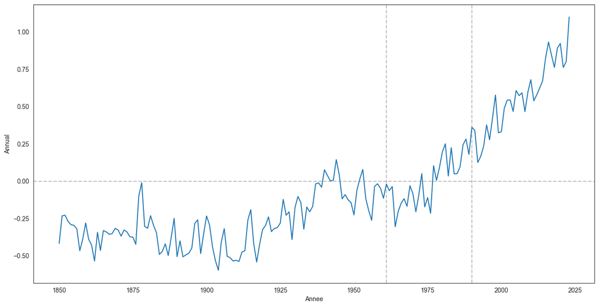

```python
plt.figure(figsize = (16, 8))
plt.axhline(y = 0, linestyle = "dashed", color = "gray", alpha = .5)
plt.axvline(x = 1961, linestyle = "dashed", color = "gray", alpha = .5)
plt.axvline(x = 1990, linestyle = "dashed", color = "gray", alpha = .5)
seaborn.lineplot(x = "Annee", y = "Annual",
                 data = temp.assign(Annee = temp.index).reset_index(drop=True))
plt.show()
```

## Analyse

on enlève la dernière colonne, qui est l'anomalie annuelle.

```python
temp2 = temp[temp.columns[:12]]
temp2
```

|  | Jan | Feb | Mar | Apr | May | Jun | Jul | Aug | Sep | Oct | Nov | Dec |
| --- | --- | --- | --- | --- | --- | --- | --- | --- | --- | --- | --- | --- |
| 1850 | -0.675 | -0.333 | -0.591 | -0.589 | -0.509 | -0.344 | -0.160 | -0.208 | -0.385 | -0.533 | -0.283 | -0.404 |
| 1851 | -0.201 | -0.469 | -0.646 | -0.542 | -0.198 | -0.137 | -0.097 | -0.102 | -0.091 | -0.008 | -0.082 | -0.228 |
| 1852 | -0.375 | -0.477 | -0.560 | -0.585 | -0.127 | -0.084 | 0.005 | -0.136 | -0.002 | -0.172 | -0.305 | 0.065 |
| 1853 | -0.233 | -0.404 | -0.280 | -0.386 | -0.268 | -0.142 | -0.083 | -0.057 | -0.250 | -0.392 | -0.411 | -0.337 |
| 1854 | -0.381 | -0.361 | -0.243 | -0.334 | -0.289 | -0.299 | -0.179 | -0.239 | -0.217 | -0.095 | -0.410 | -0.450 |
| ... | ... | ... | ... | ... | ... | ... | ... | ... | ... | ... | ... | ... |
| 2019 | 0.800 | 0.844 | 1.076 | 0.939 | 0.778 | 0.809 | 0.857 | 0.858 | 0.803 | 0.956 | 0.937 | 1.037 |
| 2020 | 1.069 | 1.113 | 1.094 | 1.063 | 0.908 | 0.825 | 0.816 | 0.801 | 0.867 | 0.811 | 1.014 | 0.693 |
| 2021 | 0.701 | 0.565 | 0.726 | 0.760 | 0.706 | 0.713 | 0.792 | 0.799 | 0.868 | 0.907 | 0.854 | 0.751 |
| 2022 | 0.779 | 0.764 | 0.890 | 0.770 | 0.761 | 0.858 | 0.778 | 0.853 | 0.790 | 0.929 | 0.675 | 0.768 |
| 2023 | 0.779 | 0.869 | 1.125 | 0.927 | 0.871 | 1.052 | 1.150 | 1.199 | 1.352 | 1.287 | 1.334 | 1.259 |

174 rows × 12 columns

Et on réalise une ACP sur les données brutes, car les variables ont toutes la même unité, et des variations similaires.

```python
pca = PCA(n_components = 12)
pca.fit(temp2)
```

```
PCA(n_components=12)
```

On remarque que 92% de l'information est contenue dans le seul premier facteur.

```python
eig = pandas.DataFrame({
    "Dimension": ["Dim"+str(i+1) for i in range(12)],
    "Valeurs propres": pca.eigenvalues_,
    "% expliquée": pca.percentage_of_variance_,
    "% expliquée cumulée": numpy.cumsum(pca.percentage_of_variance_)
})
eig.round(2)
```

|  | Dimension | Valeurs propres | % expliquée | % expliquée cumulée |
| --- | --- | --- | --- | --- |
| 0 | Dim1 | 11.09 | 92.42 | 92.42 |
| 1 | Dim2 | 0.31 | 2.59 | 95.01 |
| 2 | Dim3 | 0.13 | 1.06 | 96.07 |
| 3 | Dim4 | 0.11 | 0.90 | 96.97 |
| 4 | Dim5 | 0.09 | 0.71 | 97.69 |
| 5 | Dim6 | 0.07 | 0.57 | 98.26 |
| 6 | Dim7 | 0.05 | 0.42 | 98.68 |
| 7 | Dim8 | 0.04 | 0.36 | 99.03 |
| 8 | Dim9 | 0.04 | 0.30 | 99.33 |
| 9 | Dim10 | 0.03 | 0.25 | 99.59 |
| 10 | Dim11 | 0.03 | 0.22 | 99.80 |
| 11 | Dim12 | 0.02 | 0.20 | 100.00 |

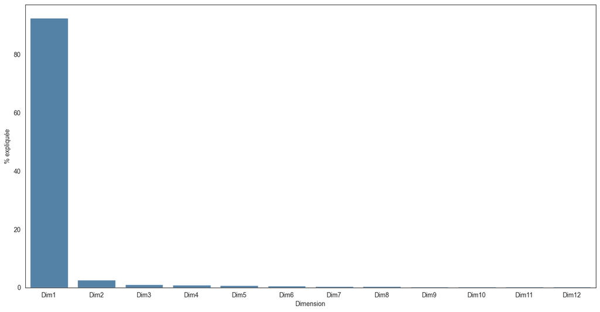

```python
plt.figure(figsize = (16, 8))
seaborn.barplot(x = "Dimension", y = "% expliquée", data = eig, color = "steelblue")
plt.show()
```

```python
pca.column_correlations.round(2)
```

| component variable | 0 | 1 | 2 | 3 | 4 | 5 | 6 | 7 | 8 | 9 | 10 | 11 |
| --- | --- | --- | --- | --- | --- | --- | --- | --- | --- | --- | --- | --- |
| Jan | 0.93 | -0.26 | -0.15 | 0.14 | 0.02 | -0.10 | -0.08 | 0.04 | 0.01 | -0.01 | -0.01 | 0.01 |
| Feb | 0.94 | -0.27 | -0.10 | 0.01 | 0.00 | 0.17 | 0.08 | -0.04 | 0.01 | 0.00 | 0.02 | 0.00 |
| Mar | 0.96 | -0.14 | 0.07 | -0.20 | -0.08 | 0.01 | -0.09 | 0.04 | 0.02 | -0.03 | 0.05 | -0.00 |
| Apr | 0.97 | -0.13 | 0.08 | -0.09 | -0.03 | -0.04 | 0.02 | -0.02 | -0.04 | 0.05 | -0.12 | -0.03 |
| May | 0.97 | -0.07 | 0.08 | -0.01 | 0.05 | -0.13 | 0.09 | -0.06 | -0.04 | 0.01 | 0.08 | 0.02 |
| Jun | 0.98 | 0.03 | 0.10 | 0.03 | 0.11 | -0.01 | 0.06 | 0.05 | 0.07 | -0.10 | -0.03 | -0.04 |
| Jul | 0.97 | 0.07 | 0.12 | 0.07 | 0.08 | 0.05 | -0.04 | 0.05 | 0.06 | 0.11 | 0.02 | 0.02 |
| Aug | 0.98 | 0.10 | 0.08 | 0.07 | -0.01 | 0.07 | -0.05 | -0.01 | -0.09 | -0.06 | -0.02 | 0.08 |
| Sep | 0.97 | 0.12 | 0.02 | 0.11 | -0.07 | 0.03 | -0.04 | -0.03 | -0.05 | 0.00 | 0.04 | -0.11 |
| Oct | 0.97 | 0.15 | -0.03 | 0.02 | -0.13 | -0.03 | -0.01 | -0.10 | 0.11 | -0.01 | -0.02 | 0.03 |
| Nov | 0.96 | 0.18 | -0.11 | -0.03 | -0.10 | -0.02 | 0.10 | 0.13 | -0.02 | 0.02 | 0.00 | 0.01 |
| Dec | 0.94 | 0.21 | -0.18 | -0.13 | 0.16 | 0.00 | -0.05 | -0.04 | -0.02 | 0.01 | -0.01 | -0.01 |

Le cercle des corrélations nous informe que les mois ont globalement tous le même comportement, et donc que les années à droite du graphique seront les années les plus chaudes.

> Vous remarquerez qu'il est plus simple à obtenir avec le module `prince`, par rapport à `sklearn`.

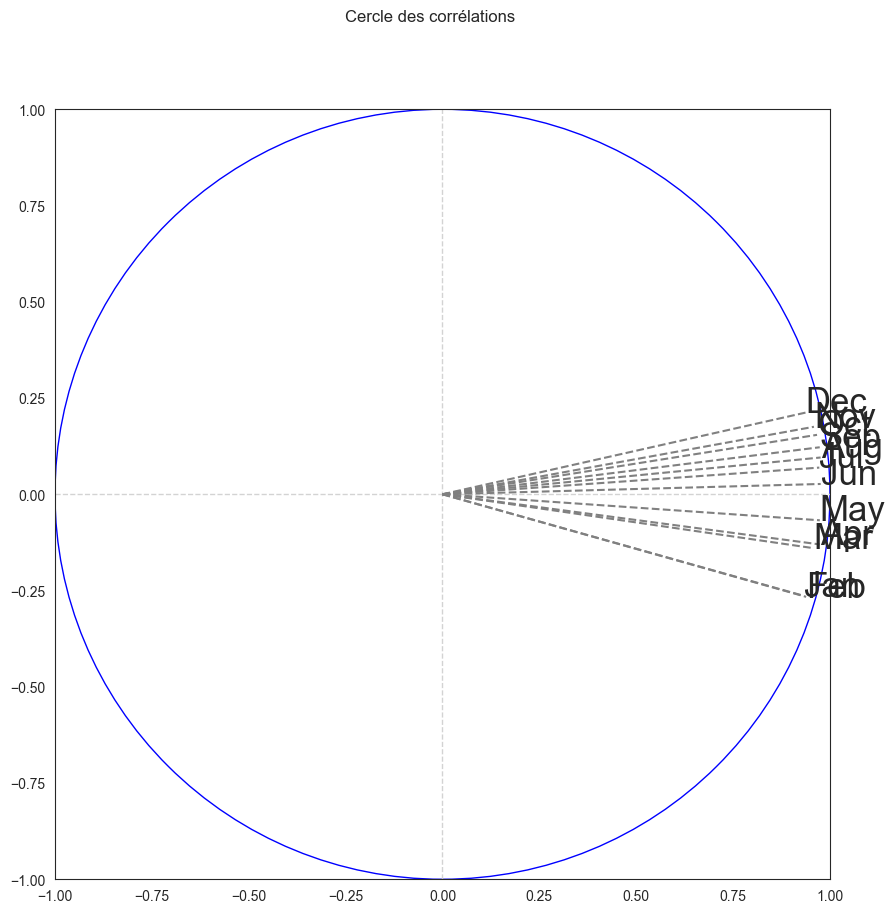

```python
coord_col = pca.column_correlations

fig, axes = plt.subplots(figsize = (10, 10))
fig.suptitle("Cercle des corrélations")
axes.set_xlim(-1, 1)
axes.set_ylim(-1, 1)
axes.axvline(x = 0, color = 'lightgray', linestyle = '--', linewidth = 1)
axes.axhline(y = 0, color = 'lightgray', linestyle = '--', linewidth = 1)
for j in range(12):
    xj = coord_col.iloc[j,0]
    yj = coord_col.iloc[j,1]
    axes.text(xj, yj, coord_col.index[j], size = 25)
    axes.plot([0,xj], [0,yj], color = "gray", linestyle = 'dashed')
plt.gca().add_artist(plt.Circle((0,0),1,color='blue',fill=False))

plt.show()
```

```python
pca.plot(temp2,
    x_component=0,
    y_component=1,
    show_rows=True,
    show_columns=False)
```

[interactive chart not shown]

```python
coord = pca.row_coordinates(temp2)
coord
```

| component | 0 | 1 | 2 | 3 | 4 | 5 | 6 | 7 | 8 | 9 | 10 | 11 |
| --- | --- | --- | --- | --- | --- | --- | --- | --- | --- | --- | --- | --- |
| 1850 | -3.012003 | 0.431466 | 0.098982 | 0.067951 | 0.351684 | 0.776386 | 0.283599 | 0.428619 | -0.153287 | 0.164669 | 0.168333 | 0.241695 |
| 1851 | -1.345836 | 0.930646 | -0.244484 | 0.877566 | 0.095484 | -0.327217 | 0.146827 | 0.047136 | 0.222303 | -0.092849 | 0.229386 | 0.193750 |
| 1852 | -1.297763 | 1.145892 | -0.017672 | 0.485128 | 0.892949 | -0.089029 | -0.121513 | -0.232531 | 0.060483 | 0.023844 | 0.559803 | -0.200627 |
| 1853 | -1.711012 | -0.078725 | 0.439443 | 0.231846 | 0.498018 | 0.059116 | -0.378079 | 0.288674 | -0.123946 | -0.158261 | 0.156853 | 0.194773 |
| 1854 | -1.917393 | -0.015155 | 0.328295 | -0.011872 | -0.298448 | 0.000950 | -0.205764 | -0.259100 | 0.332803 | 0.062479 | 0.155142 | 0.052413 |
| ... | ... | ... | ... | ... | ... | ... | ... | ... | ... | ... | ... | ... |
| 2019 | 8.475412 | 0.330155 | -0.027330 | -0.425422 | 0.042390 | 0.056811 | -0.228674 | 0.016499 | 0.122236 | 0.066653 | -0.079167 | 0.064623 |
| 2020 | 8.726627 | -0.751095 | 0.010678 | 0.015370 | -0.295516 | -0.032163 | 0.217470 | 0.304661 | -0.092436 | 0.123502 | 0.022758 | -0.139310 |
| 2021 | 7.402119 | 0.687969 | 0.207032 | 0.299010 | -0.194183 | -0.180343 | -0.140000 | -0.007238 | 0.035431 | 0.106444 | -0.033782 | -0.072324 |
| 2022 | 7.728384 | 0.150989 | 0.344504 | 0.155171 | 0.099516 | 0.005746 | -0.218616 | -0.225818 | 0.261071 | -0.290057 | 0.016249 | 0.049978 |
| 2023 | 10.419954 | 1.656237 | 0.185007 | 0.225360 | -0.289773 | 0.392665 | -0.264498 | 0.112945 | 0.024298 | -0.024447 | 0.184994 | -0.269471 |

174 rows × 12 columns

```python
contrib = pca.row_contributions_
contrib.round(2)
```

| component | 0 | 1 | 2 | 3 | 4 | 5 | 6 | 7 | 8 | 9 | 10 | 11 |
| --- | --- | --- | --- | --- | --- | --- | --- | --- | --- | --- | --- | --- |
| 1850 | 0.00 | 0.00 | 0.00 | 0.00 | 0.01 | 0.05 | 0.01 | 0.02 | 0.00 | 0.01 | 0.01 | 0.01 |
| 1851 | 0.00 | 0.02 | 0.00 | 0.04 | 0.00 | 0.01 | 0.00 | 0.00 | 0.01 | 0.00 | 0.01 | 0.01 |
| 1852 | 0.00 | 0.02 | 0.00 | 0.01 | 0.05 | 0.00 | 0.00 | 0.01 | 0.00 | 0.00 | 0.07 | 0.01 |
| 1853 | 0.00 | 0.00 | 0.01 | 0.00 | 0.02 | 0.00 | 0.02 | 0.01 | 0.00 | 0.00 | 0.01 | 0.01 |
| 1854 | 0.00 | 0.00 | 0.00 | 0.00 | 0.01 | 0.00 | 0.00 | 0.01 | 0.02 | 0.00 | 0.01 | 0.00 |
| ... | ... | ... | ... | ... | ... | ... | ... | ... | ... | ... | ... | ... |
| 2019 | 0.04 | 0.00 | 0.00 | 0.01 | 0.00 | 0.00 | 0.01 | 0.00 | 0.00 | 0.00 | 0.00 | 0.00 |
| 2020 | 0.04 | 0.01 | 0.00 | 0.00 | 0.01 | 0.00 | 0.01 | 0.01 | 0.00 | 0.00 | 0.00 | 0.00 |
| 2021 | 0.03 | 0.01 | 0.00 | 0.00 | 0.00 | 0.00 | 0.00 | 0.00 | 0.00 | 0.00 | 0.00 | 0.00 |
| 2022 | 0.03 | 0.00 | 0.01 | 0.00 | 0.00 | 0.00 | 0.01 | 0.01 | 0.01 | 0.02 | 0.00 | 0.00 |
| 2023 | 0.06 | 0.05 | 0.00 | 0.00 | 0.01 | 0.01 | 0.01 | 0.00 | 0.00 | 0.00 | 0.01 | 0.02 |

174 rows × 12 columns

## Représentation des années

On peut maintenant representer les années sur le premier plan factoriel. On voit bien que les dernières années sont les plus chaudes.

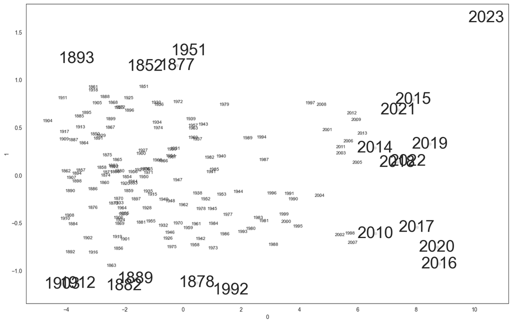

```python
plt.figure(figsize = (16, 10))
seaborn.scatterplot(x = 0, y = 1, data = coord, color = "gray", alpha = .25)
for i in range(coord.shape[0]):
    taille = "small"
    if (contrib.iloc[i,0] > .02):
        taille = 30
    if (contrib.iloc[i,1] > .02):
        taille = 30
    plt.text(coord.iloc[i][0], coord.iloc[i][1], coord.index[i],
             fontsize = taille, ha = "center", va = "center")
```

```python
pandas.DataFrame(temp.mean()).transpose().round(3).rename(index = {0: "Moyenne"})
```

|  | Jan | Feb | Mar | Apr | May | Jun | Jul | Aug | Sep | Oct | Nov | Dec | Annual |
| --- | --- | --- | --- | --- | --- | --- | --- | --- | --- | --- | --- | --- | --- |
| Moyenne | -0.099 | -0.096 | -0.115 | -0.084 | -0.089 | -0.062 | -0.038 | -0.022 | -0.039 | -0.037 | -0.075 | -0.11 | -0.072 |

```python
temp.filter(items = [1852, 1877, 1893, 1951], axis = 0)
```

|  | Jan | Feb | Mar | Apr | May | Jun | Jul | Aug | Sep | Oct | Nov | Dec | Annual |
| --- | --- | --- | --- | --- | --- | --- | --- | --- | --- | --- | --- | --- | --- |
| 1852 | -0.375 | -0.477 | -0.560 | -0.585 | -0.127 | -0.084 | 0.005 | -0.136 | -0.002 | -0.172 | -0.305 | 0.065 | -0.229 |
| 1877 | -0.411 | -0.209 | -0.091 | -0.346 | -0.411 | -0.138 | -0.016 | 0.211 | 0.108 | 0.113 | 0.034 | -0.056 | -0.101 |
| 1893 | -1.045 | -0.845 | -0.427 | -0.515 | -0.572 | -0.442 | -0.244 | -0.287 | -0.365 | -0.304 | -0.405 | -0.485 | -0.495 |
| 1951 | -0.360 | -0.509 | -0.262 | -0.108 | 0.032 | 0.060 | 0.039 | 0.121 | 0.132 | 0.124 | -0.072 | 0.069 | -0.061 |

```python
temp.filter(items = [1878, 1882, 1903, 1912, 1992], axis = 0)
```

|  | Jan | Feb | Mar | Apr | May | Jun | Jul | Aug | Sep | Oct | Nov | Dec | Annual |
| --- | --- | --- | --- | --- | --- | --- | --- | --- | --- | --- | --- | --- | --- |
| 1878 | -0.070 | 0.229 | 0.361 | 0.189 | -0.122 | 0.010 | -0.077 | -0.047 | 0.021 | -0.165 | -0.143 | -0.323 | -0.011 |
| 1882 | -0.025 | -0.117 | -0.177 | -0.315 | -0.326 | -0.392 | -0.341 | -0.245 | -0.150 | -0.399 | -0.404 | -0.655 | -0.296 |
| 1903 | -0.434 | -0.240 | -0.398 | -0.588 | -0.516 | -0.548 | -0.505 | -0.601 | -0.560 | -0.665 | -0.630 | -0.714 | -0.533 |
| 1912 | -0.329 | -0.315 | -0.554 | -0.338 | -0.335 | -0.285 | -0.507 | -0.572 | -0.644 | -0.679 | -0.558 | -0.590 | -0.476 |
| 1992 | 0.363 | 0.348 | 0.309 | 0.162 | 0.168 | 0.156 | 0.005 | 0.038 | -0.090 | -0.023 | -0.037 | 0.099 | 0.125 |

### Années (beaucoup) plus chaudes que la moyenne

```python
temp.filter(items = [i for i in range(2015, 2022)], axis = 0)
```

|  | Jan | Feb | Mar | Apr | May | Jun | Jul | Aug | Sep | Oct | Nov | Dec | Annual |
| --- | --- | --- | --- | --- | --- | --- | --- | --- | --- | --- | --- | --- | --- |
| 2015 | 0.740 | 0.782 | 0.795 | 0.701 | 0.731 | 0.760 | 0.715 | 0.799 | 0.826 | 1.015 | 0.996 | 1.042 | 0.825 |
| 2016 | 1.088 | 1.224 | 1.182 | 1.030 | 0.880 | 0.777 | 0.778 | 0.949 | 0.846 | 0.819 | 0.844 | 0.779 | 0.933 |
| 2017 | 0.952 | 1.067 | 1.065 | 0.846 | 0.780 | 0.658 | 0.805 | 0.811 | 0.729 | 0.809 | 0.806 | 0.815 | 0.845 |
| 2018 | 0.711 | 0.796 | 0.790 | 0.822 | 0.713 | 0.738 | 0.733 | 0.735 | 0.676 | 0.869 | 0.745 | 0.824 | 0.763 |
| 2019 | 0.800 | 0.844 | 1.076 | 0.939 | 0.778 | 0.809 | 0.857 | 0.858 | 0.803 | 0.956 | 0.937 | 1.037 | 0.891 |
| 2020 | 1.069 | 1.113 | 1.094 | 1.063 | 0.908 | 0.825 | 0.816 | 0.801 | 0.867 | 0.811 | 1.014 | 0.693 | 0.923 |
| 2021 | 0.701 | 0.565 | 0.726 | 0.760 | 0.706 | 0.713 | 0.792 | 0.799 | 0.868 | 0.907 | 0.854 | 0.751 | 0.762 |

## Heatmap classique de lévolution pour repérer les années à comportement atypique

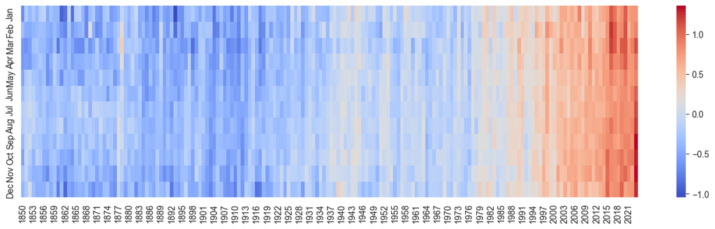

```python
plt.figure(figsize = (16, 4))
g = seaborn.heatmap(temp2.T, cmap = "coolwarm")
```

## Et avec une AFC ?

Les données doivent être toutes positives, donc on ajoute une valeur fixe à toutes les valeurs.

```python
from prince import CA

ca = CA()
ca.fit(temp2 + 100)
```

```
<prince.ca.CA at 0x13cd60520>
```

```python
ca_row = ca.row_coordinates(temp2)
ca_col = ca.column_coordinates(temp2)
```

La méthode ne semble pas pertinente dans ce cas, ou alors bien trop complexe à analyser et utiliser.

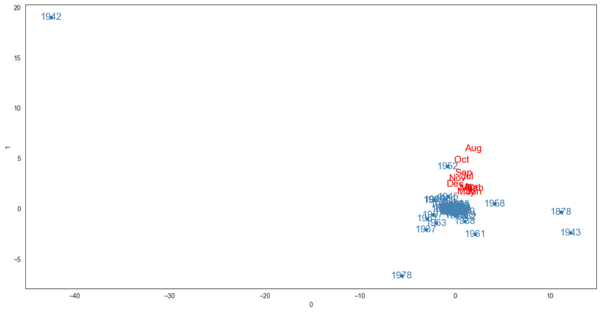

```python
plt.figure(figsize = (16, 8))

g = seaborn.scatterplot(x = 0, y = 1, data = ca_row)
for i in range(ca_row.shape[0]):
    plt.text(ca_row.iloc[i][0], ca_row.iloc[i][1], ca_row.index[i],
             ha = "center", va = "center", fontsize = 15, color = "steelblue")
for i in range(ca_col.shape[0]):
    plt.text(ca_col.iloc[i][0], ca_col.iloc[i][1],
             ca_col.index[i].replace(" Actifs ayant un emploi RP1968", ""),
             ha = "center", va = "center", fontsize = 15, color = "red")

ax = plt.gca()
plt.show()
```

```python
temp.filter(items = [i for i in [1878, 1942, 1943, 1978]], axis = 0)
```

|  | Jan | Feb | Mar | Apr | May | Jun | Jul | Aug | Sep | Oct | Nov | Dec | Annual |
| --- | --- | --- | --- | --- | --- | --- | --- | --- | --- | --- | --- | --- | --- |
| 1878 | -0.070 | 0.229 | 0.361 | 0.189 | -0.122 | 0.010 | -0.077 | -0.047 | 0.021 | -0.165 | -0.143 | -0.323 | -0.011 |
| 1942 | 0.258 | 0.017 | -0.042 | -0.015 | 0.124 | 0.030 | -0.060 | -0.057 | -0.013 | -0.087 | -0.058 | -0.080 | 0.001 |
| 1943 | -0.183 | -0.031 | -0.168 | 0.023 | 0.036 | -0.075 | 0.018 | 0.032 | -0.013 | 0.228 | 0.104 | 0.106 | 0.006 |
| 1978 | 0.037 | 0.074 | 0.059 | 0.053 | 0.012 | -0.055 | 0.016 | -0.217 | 0.042 | -0.060 | 0.092 | 0.010 | 0.005 |

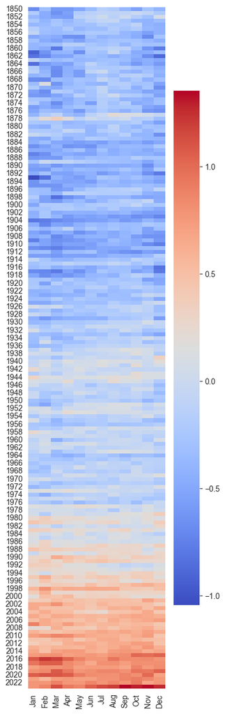

```python
plt.figure(figsize = (4, 16))
g = seaborn.heatmap(temp2, cmap = "coolwarm")
```